# What To Eat? Our Fast Food Menu Analysis

Study Group 10

2021-12-01

# 1 Introduction

Our final project aims to explore the health level of fast food restaurants in United States and nutritional value of their items. This project will focus on four fast food restaurants including McDonald’s, Subway, Burger King, and Taco Bell. After exploring the calorie distribution of restaurants, we created our own quantitative measure of healthiness through the macro-nutrient balance score to further investigate the health level of those fast food restaurants. Furthermore, we identified menu items that are vegetarian and pescetarian friendly and provide information about the degree of vegetarian and pescetarian friendly of each restaurant.

# 2 Statement of Purpose

To create intuitive visualizations that will allow consumers to make quick and informative choices about their meals when going to one of the four fast food restaurants we focused on for this project. We try to include information that will allow diverse consumers (ex: vegetarian/pescetarian, health-conscious) to come to their own conclusion about which meal from which restaurant they should get for their next meal.

# 3 Background and Preparation

We utilized 4 separate data sets to create our visualizations:

- Data set 1: Fast food menu items and their nutritional values from tidytuesday in 2018 in the United States
- Data set 2: Fast food restaurants and their locations from Kaggle in 2018 in the United States
- Data set 3: US State names and their abbreviations
- Data set 4: US State population sizes

It is important to note that the first two data sets do not include all current fast food menu items nor locations as the data is from 2018 and takes samples of locations from various locations of the country. As such, the analysis we could conduct was limited. In our analysis, however, we first focused our analysis to the 4 largest fast food restaurants: McDonald’s, Burger King, Subway, and Taco Bell. To prepare the data for analysis, we deleted irrelevant columns and NAs, adjusted state names if necessary, and made all string variables (restaurant and menu item names) lowercase without special characters so as to standardize the data for easier analysis. We then combined data sets through inner_join operations. The location data in data sets 3 and 4 were ultimately not used, as the conclusions we could reach from the mapped data was irrelevant to the story we wanted to tell.

# 4 Methodology

Overall, we utilized R packages such as dplyr to sort through the data and create relevant insights such as macro-nutrient balance scores and recognizing vegetarian/pescetarian menu items from the item names. We also utilized machine learning algorithms such as K-means to classify the menu items. The methodologies for each plot is described below with their respective codes. In order to narrate our story, we divide our presentation into two parts and a total of 6 plots and lists:

- **1: Healthiness assessment of each restaurant and their menu items**
  - Calorie distribution graph for each restaurant
  - Distribution of macro-nutrient balance scores for each menu item
  - Rankings of menu items with the best and worst macro-nutrient balance scores
  - Clustering menu items based on their various features (beyond the macros)
- **2: Providing information for diverse consumers (vegetarians and pescetarians)**
  - Key word analysis of menu items using word cloud
  - Finding which restaurant is more vegetarian and or pescetarian friendly

# 5 Results and Conclusions

In the following sections, we will share the codes that we used to clean, analyze, and graph the data before creating our final visuals on Tableau.

## 5.1 Loading the data

```r
calories <- read_csv('data/fastfood_calories.csv') %>%
  clean_names() %>%
  rename(total_prot=protein) %>%
  mutate(restaurant=str_replace_all(tolower(restaurant), '[^\\w]', '')) %>%
  filter(
    !is.na(fiber),
    !is.na(total_prot),
    restaurant %in% c('mcdonalds', 'burgerking', 'tacobell', 'subway')) %>%
  select(-x1, -vit_a, -vit_c, -calcium, -salad)

restaurants <- read_csv('data/FastFoodRestaurants.csv') %>%
  clean_names() %>%
  mutate(
    state=if_else(province == 'Co Spgs', 'CO', province),
    name=str_replace_all(tolower(name), '[^\\w]', '')) %>%
  filter(name %in% unique(calories$restaurant)) %>%
  select(-address, -country, -keys, -postal_code, -province, -websites)

abbrevs <- read_csv('data/state-abbrevs.csv') %>%
  clean_names()

population <- read_csv('data/us_pop.csv') %>%
  clean_names() %>%
  left_join(abbrevs, by='state') %>%
  select(-state) %>%
  rename(state=abbreviation)
```

## 5.2 1. Calorie distribution

**Question answered:** What is the distribution of calories for each restaurant?

We observed the distribution of the menu items for each of the four restaurants, resulting in the following density plot:

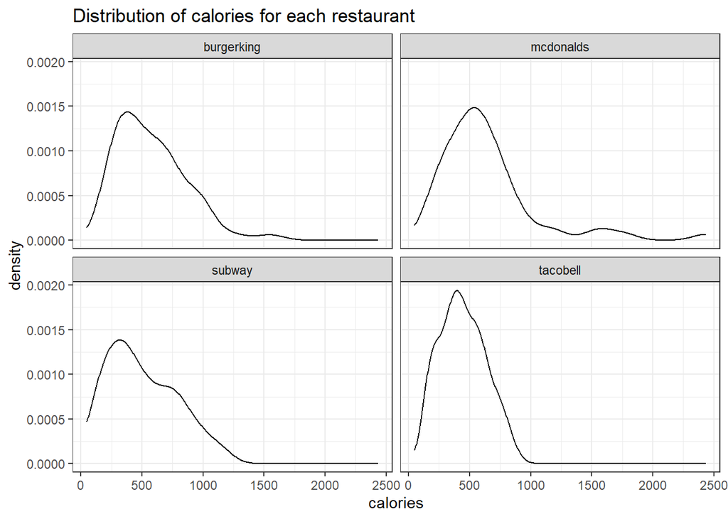

```r
calories %>%
  ggplot() +
  geom_density(aes(x=calories)) +
  facet_wrap(~restaurant)+
  theme_bw()+
  labs(title = "Distribution of calories for each restaurant")
```

## 5.3 2. Macro-nutrient balance score boxplot

**Question answered:** What is the distribution of the macro-nutrient balance scores? The macro-nutrient balance score for each macro nutrient is calculated by multiplying total_carb_grams with the number of calories per gram (4 for carb, 4 for protein, 9 for fat), dividing by the total_calories in an item to get precentage and subtracting benchmark (50 carb, 30 fat, 20 protein) from the division result. The overall macro-nutrient balance score is calculated with the following equation: *macro-nutrient _balance_score=score_prot-(score_carb+score_fat)*

Then, we observed the distribution of the macro-nutrient balance scores for all menu items for each restaurant using boxplots:

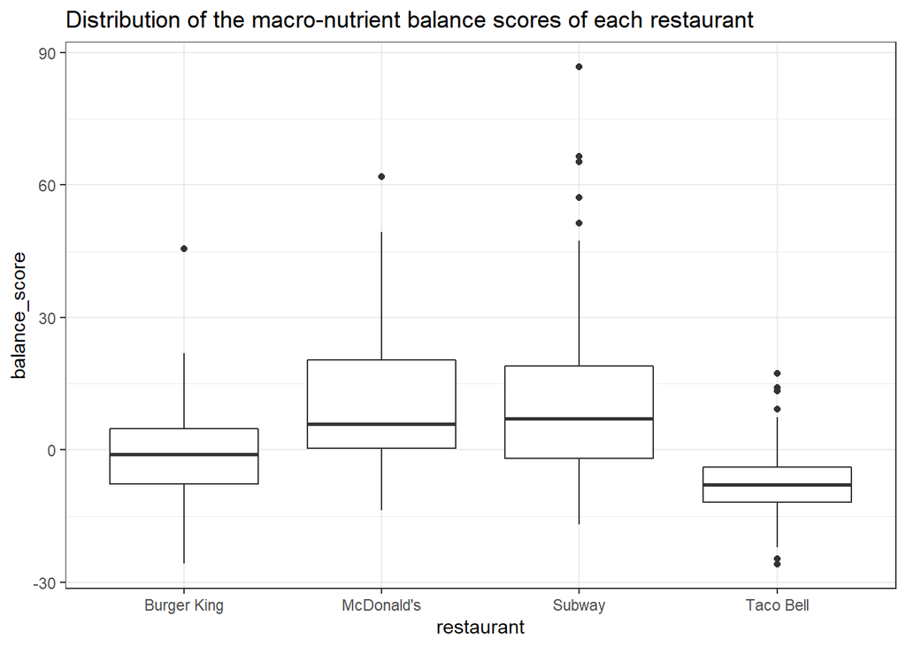

```r
balance_scores <- calories %>%
  mutate(
    score_carb=4*total_carb/calories-0.5,
    score_fat=9*total_fat/calories-0.3,
    score_prot=4*total_prot/calories-0.2,
    balance_score=score_prot-(score_carb+score_fat),
    balance_score=round(balance_score*100, 1)) %>%
  mutate(item_clean=str_replace_all(tolower(item), '[^\\s\\w]', '')) %>%
  mutate(restaurant=case_when(
    restaurant=='mcdonalds'~'McDonald\'s',
    restaurant=='burgerking'~'Burger King',
    restaurant=='tacobell'~'Taco Bell',
    restaurant=='subway'~'Subway')) %>%
  select(restaurant, item, item_clean, calories, balance_score)

balance_scores %>%
  ggplot(aes(x=restaurant, y=balance_score)) +
  geom_boxplot()+
  theme_bw()+
  labs(title = "Distribution of the macro-nutrient balance scores of each restaurant")
```

## 5.4 3. Healthiest and unhealthiest menu items

**Question answered:** Which menu items from which restaurants are the the most macro-nutrient balanced (healthiest)/ least balanced (unhealthiest)?

Using the macro-nutrient balance scores calculated above, we sliced the five most balanced (healthy) menu items and then the five least balanced (unhealthy) menu items.

```r
balance_scores %>%
  slice_max(order_by=balance_score, n=5) %>%
  pander::pander()
```

Table continues below

| restaurant | item | item_clean |
| --- | --- | --- |
| Subway | Double Chicken Salad | double chicken salad |
| Subway | Oven Roasted Chicken Salad | oven roasted chicken salad |
| Subway | Carved Turkey Salad | carved turkey salad |
| McDonald’s | Premium Bacon Ranch Salad w/ Grilled Chicken | premium bacon ranch salad w grilled chicken |
| Subway | Roast Beef Salad | roast beef salad |

| calories | balance_score |
| --- | --- |
| 220 | 86.8 |
| 140 | 66.4 |
| 150 | 65.3 |
| 320 | 61.9 |
| 140 | 57.1 |

```r
balance_scores %>%
  slice_min(order_by=balance_score, n=5) %>%
  pander::pander()
```

Table continues below

| restaurant | item | item_clean |
| --- | --- | --- |
| Taco Bell | Nacho Fries Bellgrande | nacho fries bellgrande |
| Burger King | Side Garden Salad and Avocado Ranch Dressing | side garden salad and avocado ranch dressing |
| Taco Bell | Triple Layer Nachos | triple layer nachos |
| Burger King | Side Caesar Salad with dressing | side caesar salad with dressing |
| Taco Bell | Spicy Potato Soft Taco | spicy potato soft taco |

| calories | balance_score |
| --- | --- |
| 710 | -25.8 |
| 230 | -25.7 |
| 320 | -24.7 |
| 220 | -23.6 |
| 250 | -22 |

## 5.5 4. Modelling:K-Means Clustering

```r
calories_clust <- read_csv('data/fastfood_calories.csv') %>%
  clean_names() %>%
  rename(total_prot=protein) %>%
  mutate(restaurant=str_replace_all(tolower(restaurant), '[^\\w]', '')) %>%
  filter(
    !is.na(fiber),
    !is.na(total_prot),
    restaurant %in% c('mcdonalds', 'burgerking', 'tacobell', 'subway')) %>%
  select(calories, cal_fat, total_fat, sat_fat, trans_fat, cholesterol, sodium, total_carb, fiber, sugar, total_prot)

skimr::skim(calories_clust)
```

Data summary

| Name | calories_clust |
| --- | --- |
| Number of rows | 328 |
| Number of columns | 11 |
| _______________________ |  |
| Column type frequency: |  |
| numeric | 11 |
| ________________________ |  |
| Group variables | None |

**Variable type: numeric**

| skim_variable | n_missing | complete_rate | mean | sd | p0 | p25 | p50 | p75 | p100 | hist |
| --- | --- | --- | --- | --- | --- | --- | --- | --- | --- | --- |
| calories | 0 | 1 | 519.42 | 288.87 | 50 | 320.00 | 480 | 670.0 | 2430 | ▇▆▁▁▁ |
| cal_fat | 0 | 1 | 221.38 | 161.97 | 10 | 110.00 | 190 | 292.5 | 1270 | ▇▃▁▁▁ |
| total_fat | 0 | 1 | 24.59 | 17.76 | 1 | 12.00 | 21 | 32.0 | 141 | ▇▃▁▁▁ |
| sat_fat | 0 | 1 | 7.48 | 5.66 | 0 | 4.00 | 6 | 10.0 | 47 | ▇▂▁▁▁ |
| trans_fat | 0 | 1 | 0.39 | 0.78 | 0 | 0.00 | 0 | 0.5 | 8 | ▇▁▁▁▁ |
| cholesterol | 0 | 1 | 68.20 | 67.78 | 0 | 30.00 | 50 | 85.0 | 805 | ▇▁▁▁▁ |
| sodium | 0 | 1 | 1188.37 | 697.11 | 20 | 707.50 | 1070 | 1480.0 | 6080 | ▇▅▁▁▁ |
| total_carb | 0 | 1 | 47.64 | 26.39 | 7 | 28.00 | 46 | 62.0 | 156 | ▆▇▃▁▁ |
| fiber | 0 | 1 | 4.92 | 3.13 | 0 | 3.00 | 4 | 7.0 | 17 | ▇▇▅▁▁ |
| sugar | 0 | 1 | 7.61 | 7.58 | 0 | 4.00 | 6 | 9.0 | 87 | ▇▁▁▁▁ |
| total_prot | 0 | 1 | 27.35 | 19.54 | 3 | 14.75 | 23 | 35.0 | 186 | ▇▂▁▁▁ |

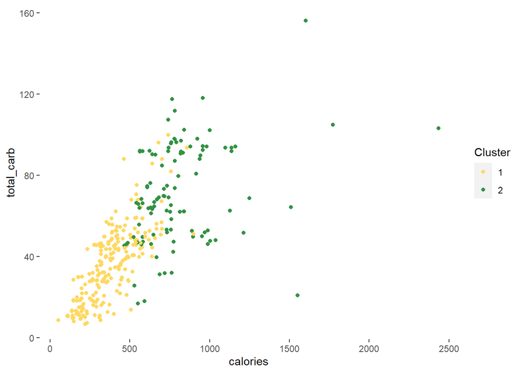

```r
model_kmeans_2clusters<-eclust(calories_clust, "kmeans", k = 2,nstart = 50, graph = FALSE)

model_withClusters <- calories_clust %>%
  mutate(cluster = as.factor(model_kmeans_2clusters$cluster))

#Visualisations
a<-ggplot(model_withClusters, aes(x = calories, y = total_carb, color =  as.factor(cluster))) +
  geom_jitter()+labs(color = "Cluster")+
  scale_colour_manual(values = c("#fed862", "#329244"))+
  theme(
  panel.background = element_rect(fill = "white",
                                colour = "white",
                                size = 0.5, linetype = "solid"),
  panel.border = element_blank(),
          panel.grid.major = element_blank(),
          panel.grid.minor = element_blank(),
  plot.background = element_rect(fill = "white"))

# Note that geom_jitter adds a small noise to each observation so that we can see overlapping points
a
```

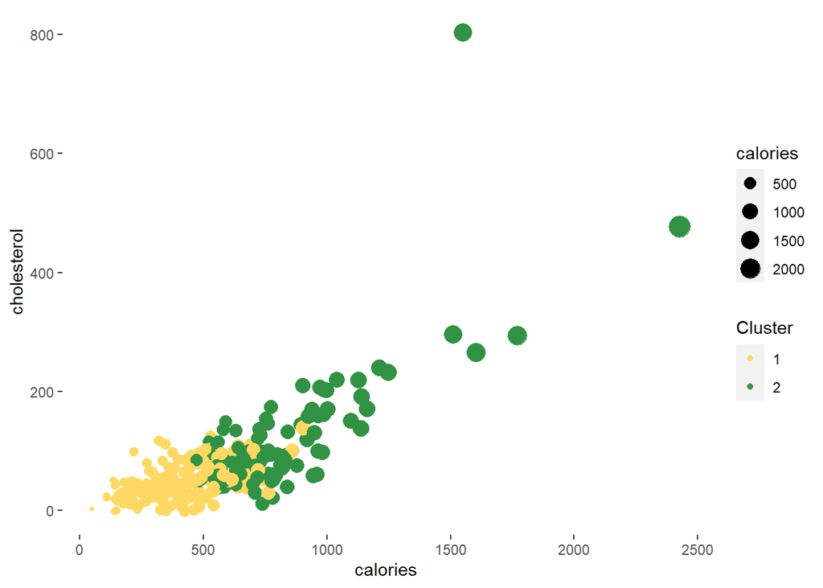

```r
b<-ggplot(model_withClusters, aes(x = calories, y = cholesterol, color = as.factor(cluster),size=calories)) +
  geom_jitter()+labs(color = "Cluster") +
  scale_colour_manual(values = c("#fed862", "#329244"))+
  theme(
  panel.background = element_rect(fill = "white",
                                colour = "white",
                                size = 0.5, linetype = "solid"),
  panel.border = element_blank(),
          panel.grid.major = element_blank(),
          panel.grid.minor = element_blank(),
  plot.background = element_rect(fill = "white"))
b
```

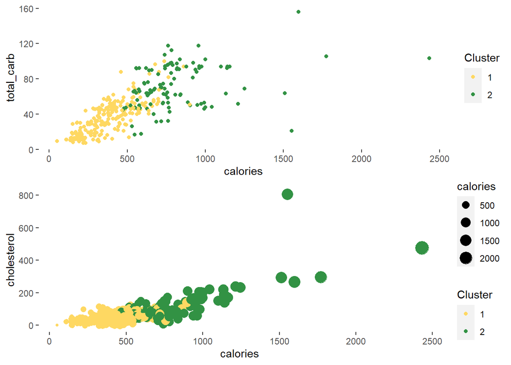

```r
#Let's arrange these visualizations so that they fit in the html file nicely
grid.arrange(a, b, nrow = 2)
```

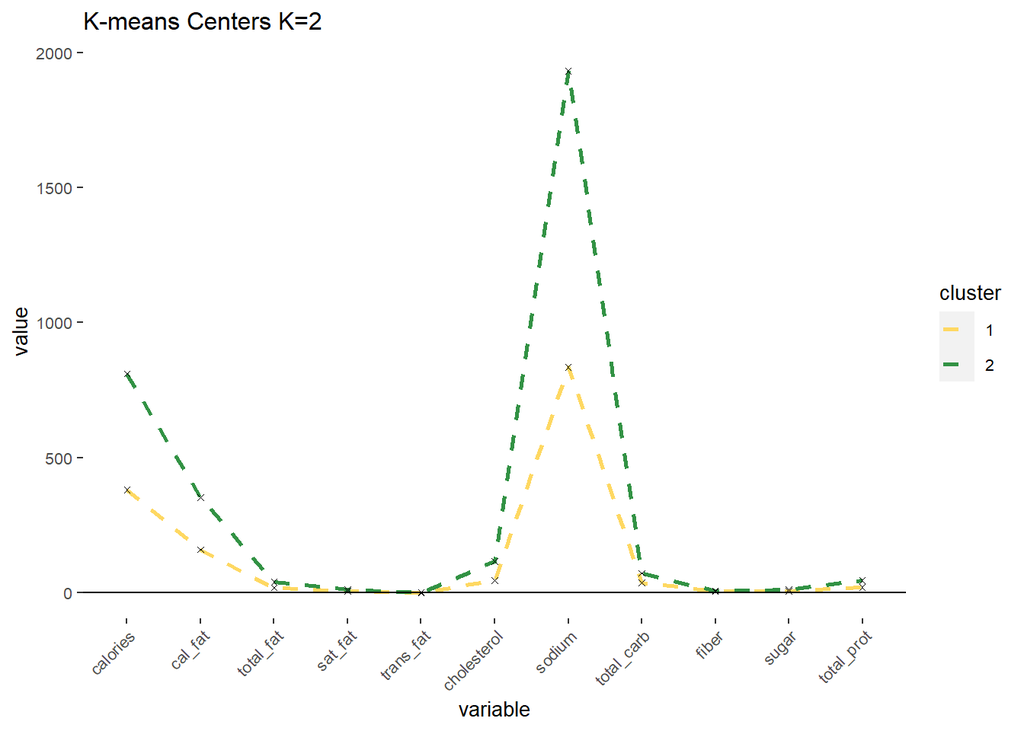

```r
#Plot centers for k=2
#First generate a new data frame with cluster centers and cluster numbers
cluster_centers<-data.frame(cluster=as.factor(c(1:2)),model_kmeans_2clusters$centers)
#transpose this data frame
cluster_centers_t<-cluster_centers %>% gather(variable,value,-cluster,factor_key = TRUE)
#plot the centers
graphkmeans_2clusters<-ggplot(cluster_centers_t, aes(x = variable, y = value))+  geom_line(aes(color =cluster,group = cluster), linetype = "dashed",size=1)+ geom_point(size=1,shape=4)+geom_hline(yintercept=0)+theme(text = element_text(size=10),axis.text.x = element_text(angle=45, hjust=1),)+ggtitle("K-means Centers K=2")+
  scale_colour_manual(values = c("#fed862", "#329244"))+
  theme(
  panel.background = element_rect(fill = "white",
                                colour = "white",
                                size = 0.5, linetype = "solid"),
  panel.border = element_blank(),
          panel.grid.major = element_blank(),
          panel.grid.minor = element_blank(),
  plot.background = element_rect(fill = "white"))
graphkmeans_2clusters
```

Below, we determine whether k=2 is optimal for clustering:

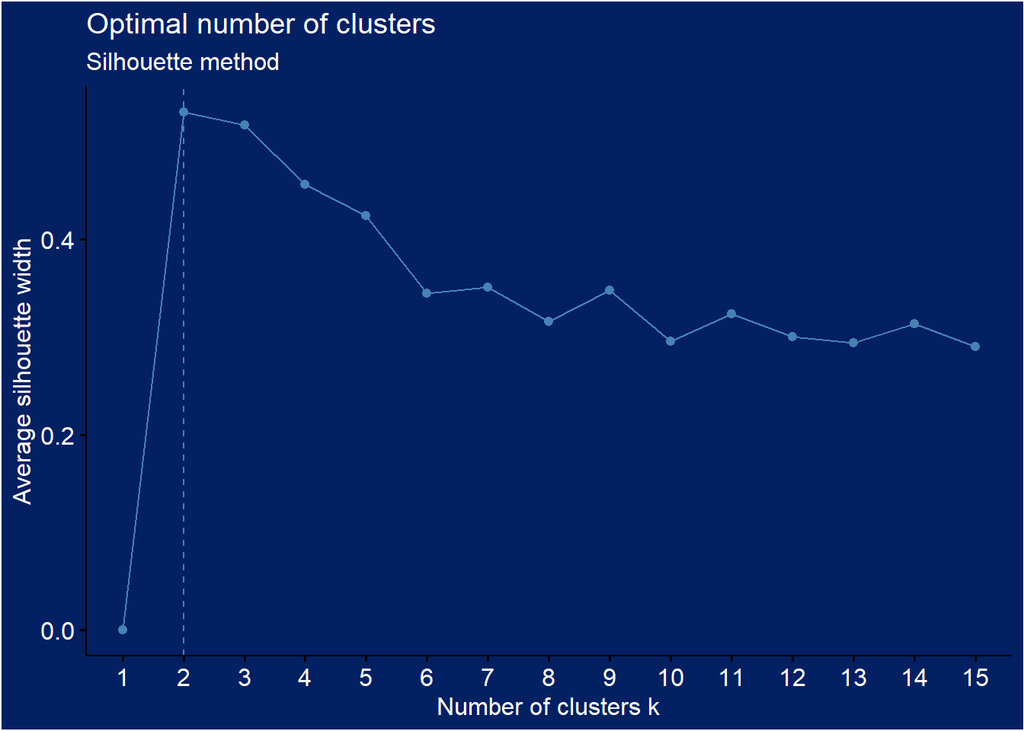

```r
#Checking if 2 is the optimal cluster
fviz_nbclust(calories_clust, kmeans, method = "silhouette",k.max = 15)+labs(subtitle = "Silhouette method")+
  scale_colour_manual(values = c("#eeb605", "white"))+
  theme(
  panel.background = element_rect(fill = "#022062",
                                colour = "#022062",
                                size = 0.5, linetype = "solid"),
  panel.border = element_blank(),
          panel.grid.major = element_blank(),
          panel.grid.minor = element_blank(),
  plot.background = element_rect(fill = "#022062"),
  axis.text = element_text(colour = "white"),
  legend.background = element_rect(fill = "#022062"),
  legend.key = element_rect(fill = "#022062"),
  text = element_text(colour = "white"),
           axis.text.y = element_text(colour = "white",
                                      family = "Montserrat"))
```

[output not shown]

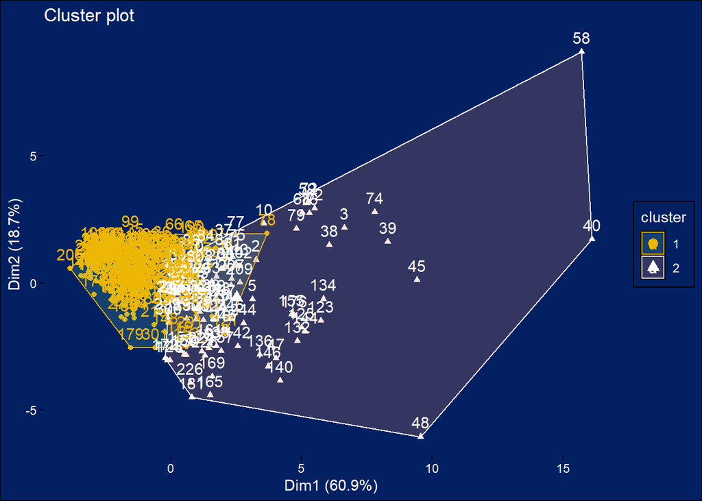

```r
#Making a plot of Clusters
fviz_cluster(model_kmeans_2clusters, calories_clust, palette = "Set2", ggtheme = theme_minimal()) +
  scale_colour_manual(values = c("#eeb605", "white"))+
  theme(
  panel.background = element_rect(fill = "#022062",
                                colour = "#022062",
                                size = 0.5, linetype = "solid"),
  panel.border = element_blank(),
          panel.grid.major = element_blank(),
          panel.grid.minor = element_blank(),
  plot.background = element_rect(fill = "#022062"),
  axis.text = element_text(colour = "white"),
  legend.background = element_rect(fill = "#022062"),
  legend.key = element_rect(fill = "#022062"),
  text = element_text(colour = "white"),
           axis.text.y = element_text(colour = "white",
                                      family = "Montserrat"))
```

## 5.6 5. Wordcloud

**Question answered:** What are the major key words found in each restaurants’ menus? Restaurants use certain key words to attract consumers and get them to buy their products. Before diving into what kind of vegetarian or pescetarian friendly menu items these corporations include in their menus, we can get an overview of the kinds of key words found in the menu overall by visualizing them in a wordcloud:

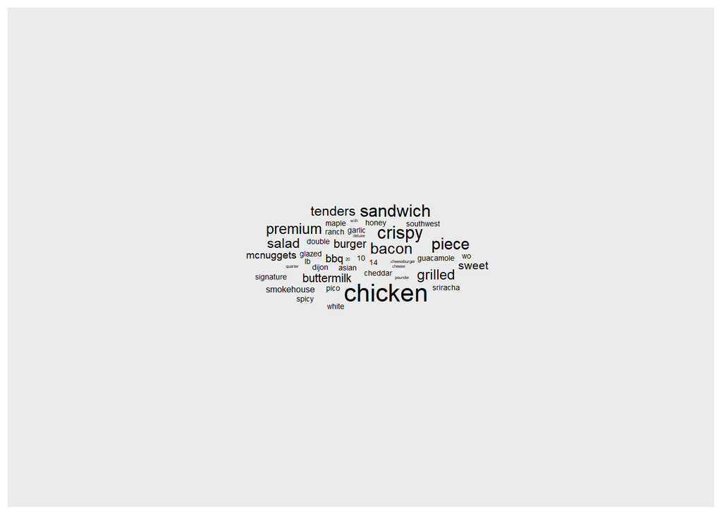

```r
make_cloud <- function(name) {
  words <- calories %>%
    filter(restaurant==name) %>%
    select(item) %>%
    mutate(item=str_replace_all(tolower(item), '[^\\s\\w]', '')) %>%
    pull()

  as.data.frame(table(unlist(strsplit(words, ' ')))) %>%
    rename(item=Var1, n=Freq) %>%
    filter(str_length(item)>1, n>1) %>%
    ggplot(aes(label=item, size=n)) +
    geom_text_wordcloud()
}

make_cloud('mcdonalds')
```

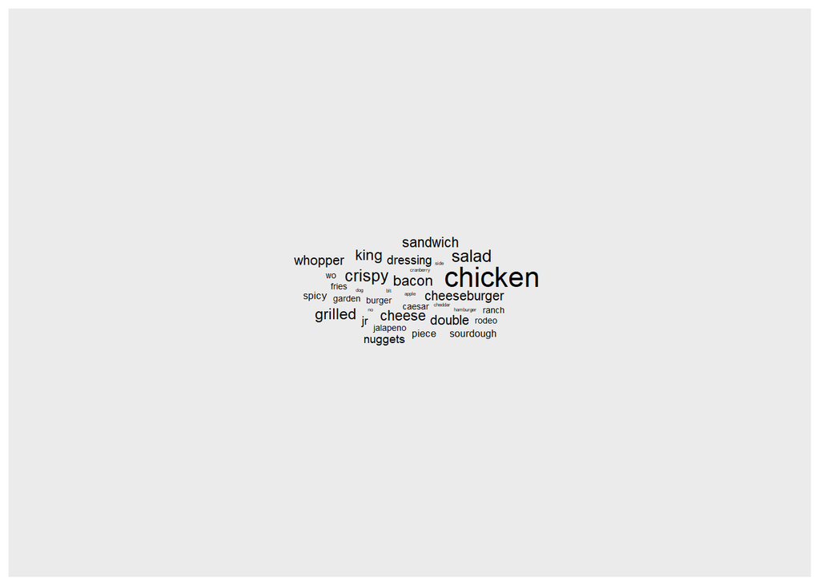

```r
make_cloud('burgerking')
```

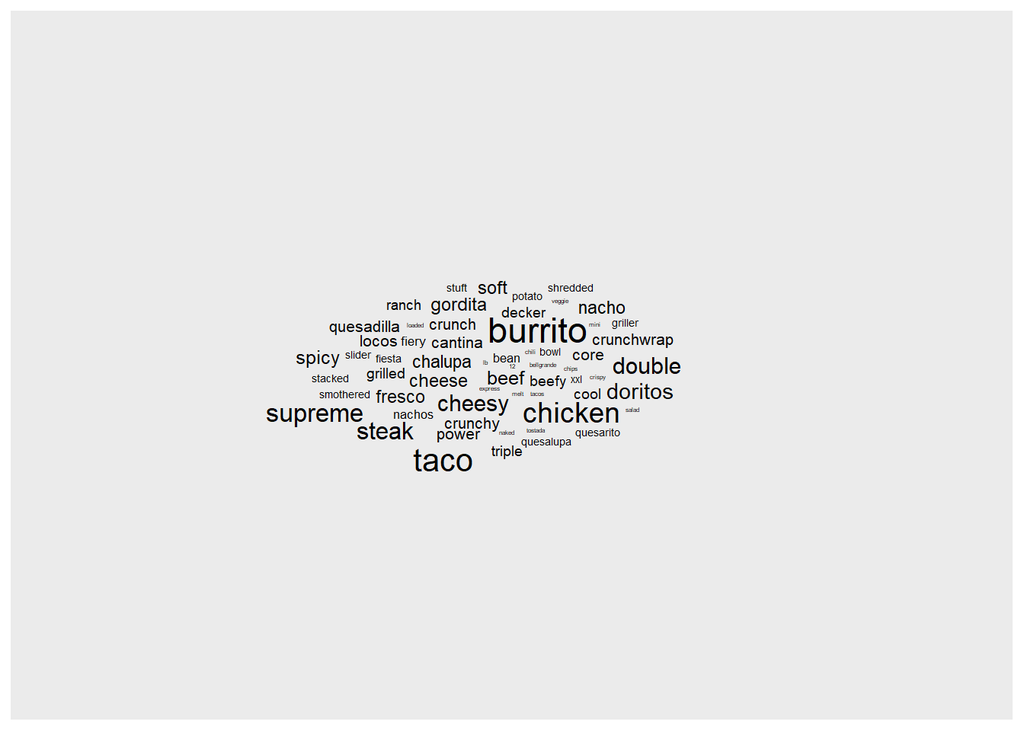

```r
make_cloud('tacobell')
```

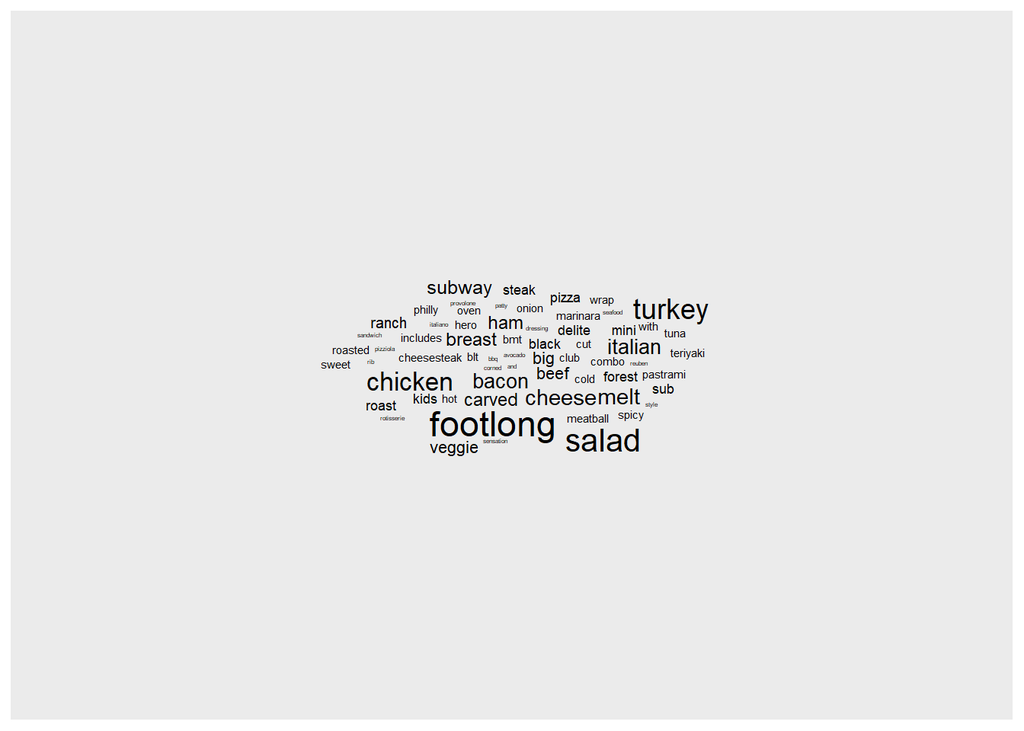

```r
make_cloud('subway')
```

## 5.7 6. Vegetarian and Pescetarian friendly restaurants

**Question answered:** Which of the four fast food restaurants is most vegetarian and or pescetarian friendly?

In this section, we explored the calories data set to find which restaurant is most vegetarian and or pescetarian friendly. We looked at each menu item name one by one to find some of the key words that can identify vegetarian or pescetarian friendly menu items. We extracted the number of vegetarian and pescetarian friendly menu items to find the percentage of menu that is vegetarian/pescetarian friendly for each restaurant. We plotted the results in a bar plot:

```r
#Vegetarian
calories_veg <- calories %>%
  mutate(item=str_replace_all(tolower(item), '[^\\s\\w]',''),
        wo = ifelse(grepl('wo chicken', item), 1, 0),
         veggie = ifelse(grepl('veggie', item), 1, 0),
        veggies = ifelse(grepl('veggies', item), 1, 0),
        cheesepizza = ifelse(grepl('cheese pizza', item),1,0),
        cheesequesadilla = ifelse(grepl('cheese quesadilla', item),1,0),
        cheeserollup = ifelse(grepl('cheese rollup', item),1,0),
        bean_burrito = ifelse(grepl('bean burrito', item),1,0),
        tostada = ifelse(grepl('spicy tostada', item),1,0),
        gardensalad = ifelse(grepl('side garden salad', item),1,0),
         total_veg = wo + veggie + veggies + cheesepizza + cheesequesadilla + cheeserollup + bean_burrito + tostada + gardensalad) %>%
  group_by(restaurant) %>%
  summarize(count = n(),
            sum_veg = sum(total_veg),
            perc = sum_veg/count * 100)

pander::pander(calories_veg)
```

| restaurant | count | sum_veg | perc |
| --- | --- | --- | --- |
| burgerking | 60 | 2 | 3.333 |
| mcdonalds | 57 | 3 | 5.263 |
| subway | 96 | 9 | 9.375 |
| tacobell | 115 | 8 | 6.957 |

[figure not shown]

```r
# R vegetarian friendly plot
veggie_plot <-
  calories_veg %>% ggplot(aes(x= reorder(restaurant, perc), y = perc, fill=factor(ifelse(restaurant=="subway","Highlighted","Normal")))) +
  geom_col() +
  theme(legend.position = "none")+
  ggtitle("Subway is the most vegetarian friendly restaurant") +
  xlab("Restaurants") +
  ylab("Percentage of menu items that are pescetarian friendly (%)")
veggie_plot
```

```r
#Pescetarian
calories_pesc <- calories %>%
  mutate(item=str_replace_all(tolower(item), '[^\\s\\w]',''),
         wo = ifelse(grepl('wo chicken', item), 1, 0),
         veggie = ifelse(grepl('veggie', item), 1, 0),
         veggies = ifelse(grepl('veggies', item), 1, 0),
         cheesepizza = ifelse(grepl('cheese pizza', item),1,0),
         cheesequesadilla = ifelse(grepl('cheese quesadilla', item),1,0),
         cheeserollup = ifelse(grepl('cheese rollup', item),1,0),
         bean_burrito = ifelse(grepl('bean burrito', item),1,0),
         tostada = ifelse(grepl('spicy tostada', item),1,0),
         gardensalad = ifelse(grepl('side garden salad', item),1,0),
         seafood = ifelse(grepl('seafood', item),1,0),
         tuna = ifelse(grepl('tuna', item),1,0),
         fish = ifelse(grepl('fish', item),1,0),
         lobster = ifelse(grepl('lobster', item),1,0),
         total_pesc = wo + veggie + veggies + cheesepizza + cheesequesadilla + cheeserollup + bean_burrito + tostada + gardensalad + seafood + tuna + fish + lobster) %>%
  group_by(restaurant) %>%
  summarize(count = n(),
            sum_pesc = sum(total_pesc),
            perc = sum_pesc/count * 100)

pander::pander(calories_pesc)
```

| restaurant | count | sum_pesc | perc |
| --- | --- | --- | --- |
| burgerking | 60 | 3 | 5 |
| mcdonalds | 57 | 5 | 8.772 |
| subway | 96 | 14 | 14.58 |
| tacobell | 115 | 8 | 6.957 |

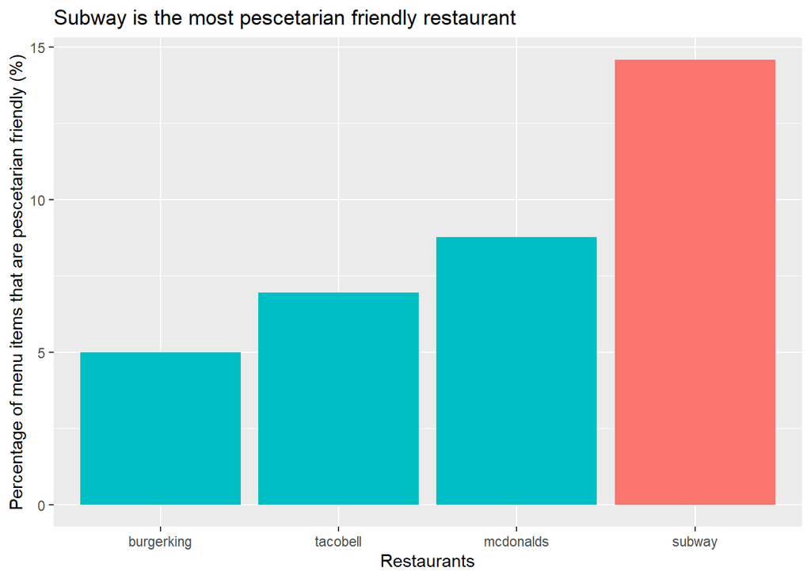

```r
# R pescetarian friendly plot
fishie_plot <-
  calories_pesc %>% ggplot(aes(x= reorder(restaurant, perc), y = perc, fill=factor(ifelse(restaurant=="subway","Highlighted","Normal")))) +
  geom_col() +
  theme(legend.position = "none")+
  ggtitle("Subway is the most pescetarian friendly restaurant") +
  xlab("Restaurants") +
  ylab("Percentage of menu items that are pescetarian friendly (%)")
fishie_plot
```

# 6 Key Findings

1. Subway has the most health-conscious menu items
2. Machine Learning naturally clumps meals together based on healthy and unhealthy factors (can be used to replace balance scores)
3. Chicken is the most common ingredient overall
4. Subway is the most inclusive restaurant

# 7 Discussion and Critique

Through the process of carrying out our project, we learned how to visualize and manipulate data through tableau and R. We met some problems when we tried to create density plots with tableau, we wish to solve this problem next time. Because we only picked four restaurants, To give people more solid suggestions on restaurants choices, we should include more restaurants and do more analysis. Also, because the data was originated in 2018, if possible, we should incorporate more updated and comprehensive data. Lastly, we mainly focused on the healthiness of the restaurants in our analysis. In the future, we can dig into the data from more varied perspectives. For example, we can check people’s preferences over different ingredients across different states.